# Domača naloga 6

Osnove teoretične statistike

Alen Kahteran

13. 03. 2020

# 1.

Opazovanja so časi med dvemi naročili. Kot je razvidno iz navodil so ti porazdeljeni kot

$$X \sim exp(\lambda) \,,$$
kjer $\lambda$ predstavlja stopnjo in je enaka $0.5$ ($30$ naročil na $60$ min $\rightarrow$ $2$ min na naročilo oz. $0.5$ naročila na minuto). Naslednji graf prikazuje porazdelitev časa med naročili.

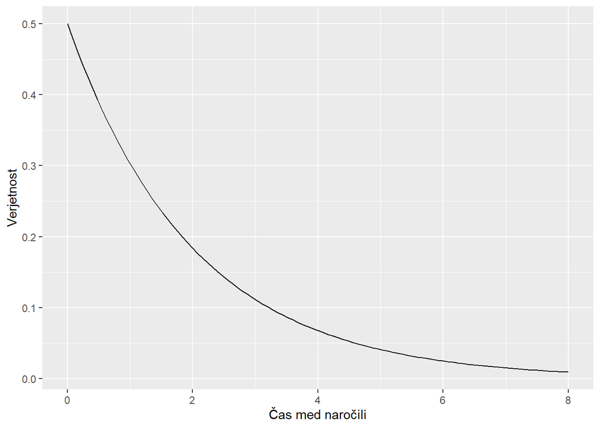

```r
ggplot(data.frame(x=seq(0, 8, 0.01)), aes(x)) +
    stat_function(fun=dexp,
                  geom="line",
                  args=list(rate=0.5)) +
    labs(x="Čas med naročili",
         y="Verjetnost")
```

Ker je cilj zabeležiti 50 različnih časov (torej 100 naročil, da bodo $X_i$ neodvisni), čigar vsota je porazdeljena po

$$\sum_{i=1}^{n}X_i \sim \Gamma(n,\lambda) \,,$$
kar je tudi prikazano na spodnjem grafu.

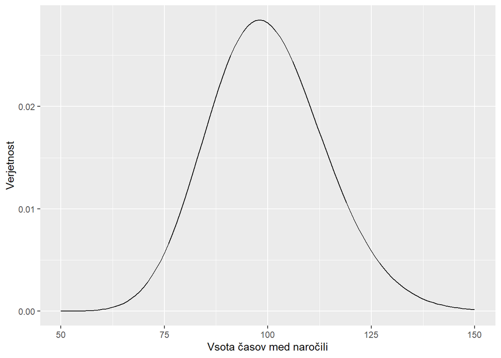

```r
ggplot(data.frame(x=seq(50, 150, 0.01)), aes(x)) +
    stat_function(fun=dgamma,
                  geom="line",
                  args=list(shape=50,
                            rate=0.5)) +
    labs(x="Vsota časov med naročili",
         y="Verjetnost")
```

# 2.

Želja je dokazati da se je število naročil povečalo. Torej, da se je čas med dvemi naročili zmanjšal (tj. $\lambda$). Se pravi ničelna domneva je

$$H_0:\lambda=0.5$$

in alternativna

$$H_0:\lambda\neq0.5 \,.$$

Domneva je enostavna dvostranska.

# 3.

Naj bo $T$ testna statistika za naš primer in je enaka

$$T = \sum_{i=1}^{n}X_i \,.$$

Predstavlja vsoto vseh časov med dvemi naročili. $T$ je porazdeljen pod $H_0$ po naslednji porazdelitvi

$$T \sim \Gamma(n=50, \lambda=0.5)$$

## a.

Poglejmo si graf z območjem zavrnitve pri $\alpha=0.05$.

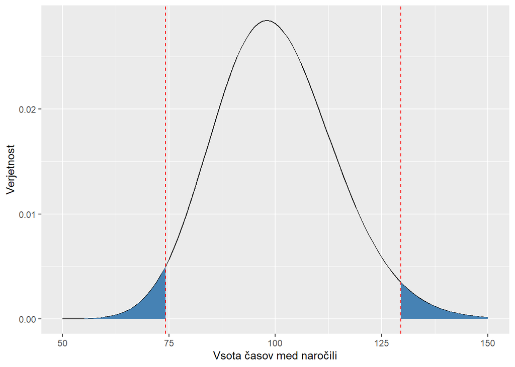

```r
ggplot(data.frame(x=seq(50, 150, 0.01)), aes(x)) +
    stat_function(fun=dgamma,
                  geom="line",
                  args=list(shape=50,
                            rate=0.5)) +
    stat_function(fun=dgamma,
                  geom="area",
                  fill="steelblue",
                  xlim=c(50, qgamma(0.025, shape = 50, rate = 0.5)),
                  args=list(shape=50,
                            rate=0.5))  +
    stat_function(fun=dgamma,
                  geom="area",
                  fill="steelblue",
                  xlim=c(qgamma(0.975, shape = 50, rate = 0.5), 150),
                  args=list(shape=50,
                            rate=0.5)) +
    geom_vline(xintercept=qgamma(0.025, shape = 50, rate = 0.5),
               linetype="dashed",
               color="red") +
        geom_vline(xintercept=qgamma(0.975, shape = 50, rate = 0.5),
               linetype="dashed",
               color="red") +
    labs(x="Vsota časov med naročili",
         y="Verjetnost")
```

Naše območje zavrnitve je $(0, 74.22]\cup[129.56, \infty]$.

## b.

Če so delavčeve domneve upravičene, pomeni da pričakujemo manjšo statistiko $T$ saj ta predstavlja vsoto časa med naročili. Torej če je več naročil, je čas med naročili krajši in posledično tudi njihova vsota.

## c.

```r
lmbd <- seq(0, 1, 0.001)

powahs <- pgamma(qgamma(0.975, shape = 50, rate = 0.5),
                 shape=50,
                 rate=lmbd) -
    pgamma(qgamma(0.025, shape = 50, rate = 0.5),
           shape=50,
           rate=lmbd)

# which(powahs>=0.2) returns indexes where that holds true, we want minimum becuase we are interested at the limit where test power is 80%
lmbd[min(which(powahs>=0.2))]
```

```
## [1] 0.34
```

Torej, minimalni povprečni čas med dvemi naročili, da imamo $80\%$ moč testa, je enak $2.94$ min ($1/0.34 = 2.94$).

# 4.

$$\Lambda = \frac{\prod_{i=1}^{n}f_0(x_i, \lambda_0)}{\prod_{i=1}^{n}f_0\left(x_i;\hat{\lambda}\right)}$$
$$\Lambda = \frac{\lambda_0^nexp\left(-\lambda_0(\sum_{i=1}^{n}x_i)\right)}{\hat{\lambda}^nexp\left(-\hat{\lambda}(\sum_{i=1}^{n}x_i)\right)}$$

$$\Lambda = \frac{\lambda_0^n}{\hat{\lambda^n}}exp\left(\sum_{i=1}^{n}x_i(\hat{\lambda} - \lambda_0)\right)$$
Malce preoblikujemo in kasneje vidimo da asimptotsko velja naslednje

$$-2\ln\Lambda=-2\ln\left(\frac{\lambda_0^n}{\hat{\lambda^n}}\right) - 2\left(\sum_{i=1}^{n}x_i(\hat{\lambda} - \lambda_0)\right)$$

$$-2\ln\Lambda= -2n(\ln\lambda_0 - \ln(\hat{\lambda})) - 2(\hat{\lambda}- \lambda_0)\sum_{i=1}^{n}x_i \sim \chi_1^2$$
kjer sem izpustil postopek za izpeljavo $\hat{\lambda}$ po metodi največjega verjetja in dobil da velja $\hat{\lambda}=\frac{n}{\sum_{i=1}^{n}x_i}=\frac{1}{\bar{X}}$.

## a.

Območje zavrnitve je $[3.84, \infty]$.

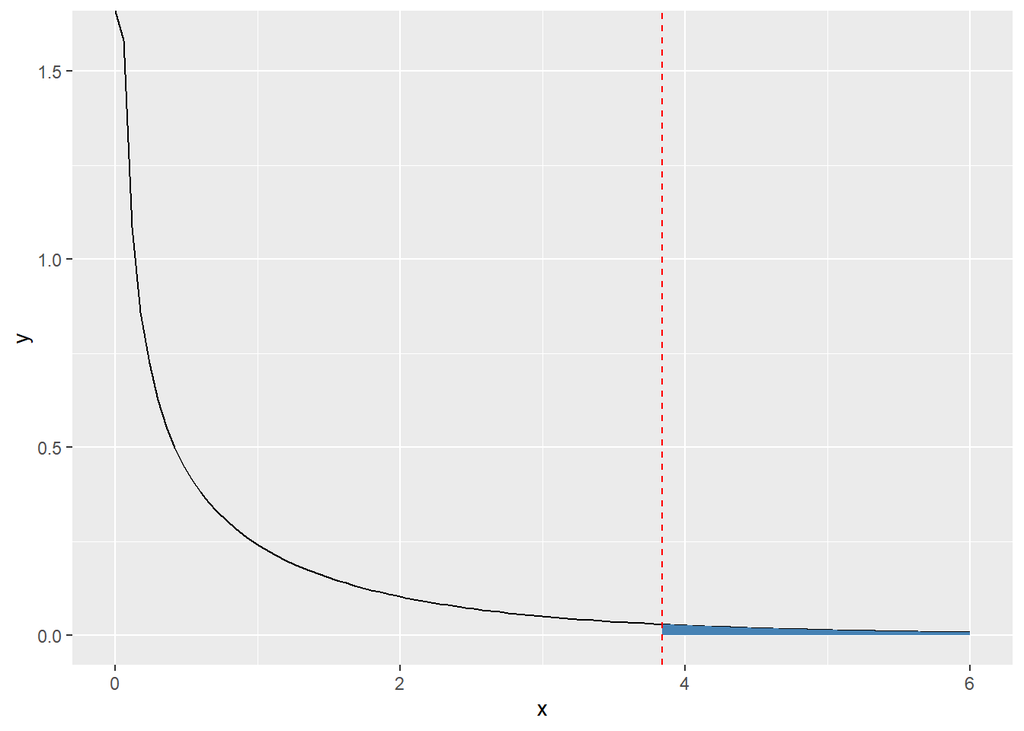

```r
ggplot(data.frame(x=seq(0, 6, 0.001)), aes(x)) +
    stat_function(fun=dchisq,
                  geom="line",
                  args=list(df=1)) +
    stat_function(fun=dchisq,
                  geom="area",
                  fill="steelblue",
                  xlim=c(qchisq(p=0.95, df=1), 6),
                  args=list(df=1)) +
    geom_vline(xintercept=qchisq(p=0.95, df=1),
               linetype="dashed",
               color="red")
```

## b.

Velikost vzorca mora biti dovolj velika zaradi asimptotske lastnosti. Odločil sem se za $10000$ ponovitev z velikostjo vzorca $10000$, saj mislim da bi vse skupaj moralo delati dovolj dobro.

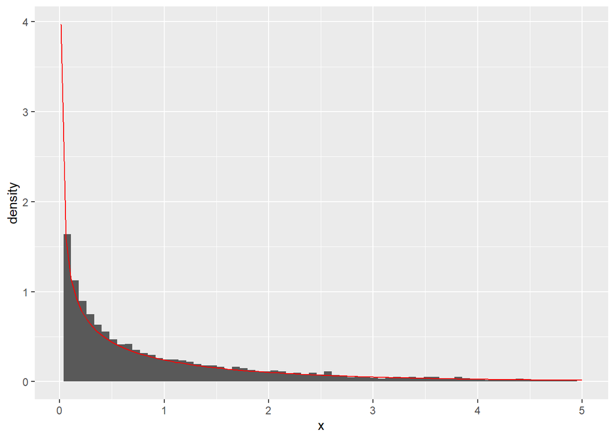

```r
set.seed(8)

# generiramo vzorce iz eksponentne
vzorci <- replicate(10000, rexp(10000, rate=0.5)) # rexp ker pod nicelno domneevo

# zracunamo lambda strehe po vrsticah
lambda_strehe <- 1/rowMeans(vzorci)

# sestejemo po vrsticah
vsota_vzorci <- rowSums(vzorci)

# izracunamo statistike T
statistike_t <- -2*10000*(log(0.5)-log(lambda_strehe)) - 2*(lambda_strehe-0.5)*vsota_vzorci

ggplot(data.frame(x=statistike_t), aes(x)) +
    geom_histogram(aes(y=..density..),
                   bins=69) +
    stat_function(fun=dchisq,
                  geom="line",
                  col="red",
                  args=list(df=1)) +
    xlim(c(0.01, 5)) # nujno 0.01 ker ce ne, narise tocko pri 1200 in ni razvidno.
```

# 5.

Pri obeh testih smo predpostavili da so $X_i$ neodvisni ($iid$), ter da je čas med naročili porazdeljen po eksponentni porazdelitvi. Razlika se je pojavila pri velikosti vzorca. Pri prvemu smo uporabili konstantno velikost $n=50$ medtem ko smo pri drugemu morali uporabiti neko veliko številko saj smo morali preverjati asimptotsko.

# 6.

```r
# generiramo vzorce iz eksponentne
statistike_t_1 <- colSums(replicate(10000, rexp(50, rate=0.5)))

# delez zavrnjenih t_1
sum(statistike_t_1 >= qgamma(0.975, shape = 50, rate = 0.5) | statistike_t_1 <= qgamma(0.025, shape = 50, rate = 0.5))/10000
```

```
## [1] 0.0497
```

```r
# statistike_t so še od prejšnjega primera in so že izračunane
sum(statistike_t >= qchisq(p=0.95, df=1))/10000
```

```
## [1] 0.05
```

V obeh primerih vidimo da je velikost testa zelo blizu $\alpha=0.05$.